# Charts For Statistical Analysis

To plot various charts, let’s first load and attach the *“Lung Capacity Dataset”.

```r
LungCapData = read.table(file = "../Dataset/LungCapData.txt", header = T, sep = "\t")
attach(LungCapData)
head(LungCapData)
```

```
##   LungCap Age Height Smoke Gender Caesarean
## 1   6.475   6   62.1    no   male        no
## 2  10.125  18   74.7   yes female        no
## 3   9.550  16   69.7    no female       yes
## 4  11.125  14   71.0    no   male        no
## 5   4.800   5   56.9    no   male        no
## 6   6.225  11   58.7    no female        no
```

The above table gives us a brief look over the data and class of each variable.

Let’s graphically analyse the variables present in the dataset :

### Barcharts

Barcharts are appropriate for summarizing the distribution of a categorical variable.

To get help on barplot in R :

```r
help("barplot") #or,
?barplot
```

A barplot is a visual display of the frequency of each category/element of a categorical variable or, the relative frequency of each category/element.

Let’s first produce a proportion table of *“Gender”* to form a barplot :

```r
Proportion = table(Gender)/length(Gender)
Proportion
```

```
## Gender
##    female      male
## 0.4937931 0.5062069
```

Now, let’s plot a barchart for the proportion table :

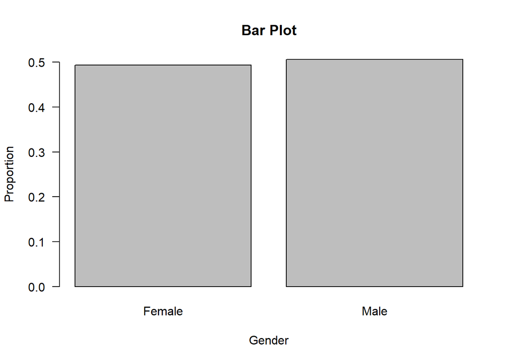

```r
barplot(Proportion,
        main = "Bar Plot",
        xlab = "Gender",
        ylab = "Proportion",
        las = 1,
        names.arg = c("Female", "Male"),
        )
```

To get a horizotal barplot, we have to pass `horiz = TRUE` argument inside `barplot()` function.

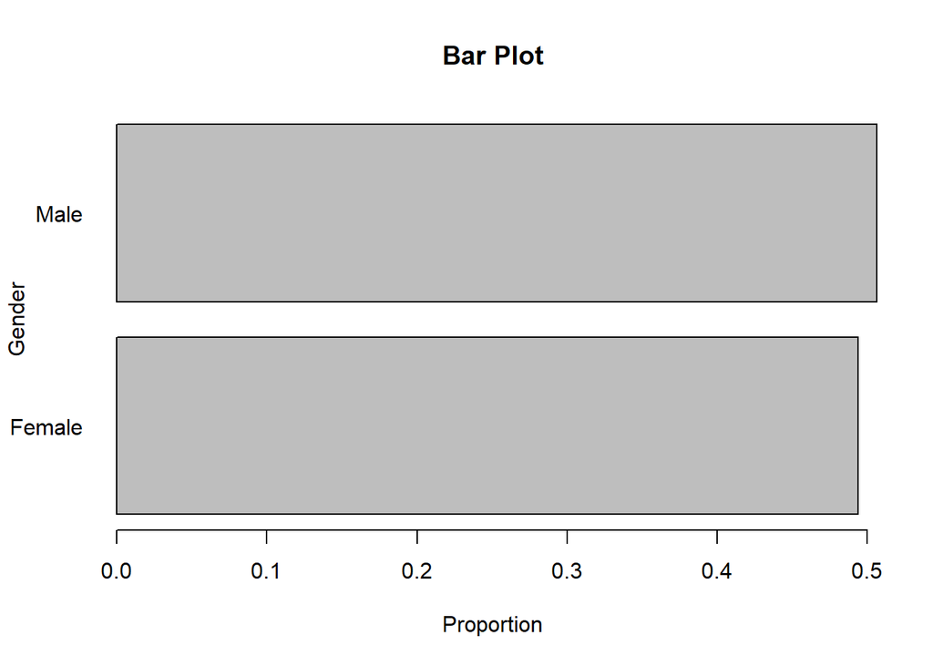

```r
barplot(Proportion,
        main = "Bar Plot",
        xlab = "Proportion",
        ylab = "Gender",
        las = 1,
        names.arg = c("Female", "Male"),
        horiz = TRUE
        )
```

### Pie Charts

Piecharts are appropriate for summarizing the distribution of a categorical variable but, its intuitive only when we have fewer categories/elements (3 or, less)

To get help on piechart in R :

```r
help("pie") #or,
?pie
```

A pie chart is a also visual display of the frequency of each category/element of a categorical variable or, the relative frequency of each category/element.

Now, let’s plot a pie chart for the *“Proportion”* table :

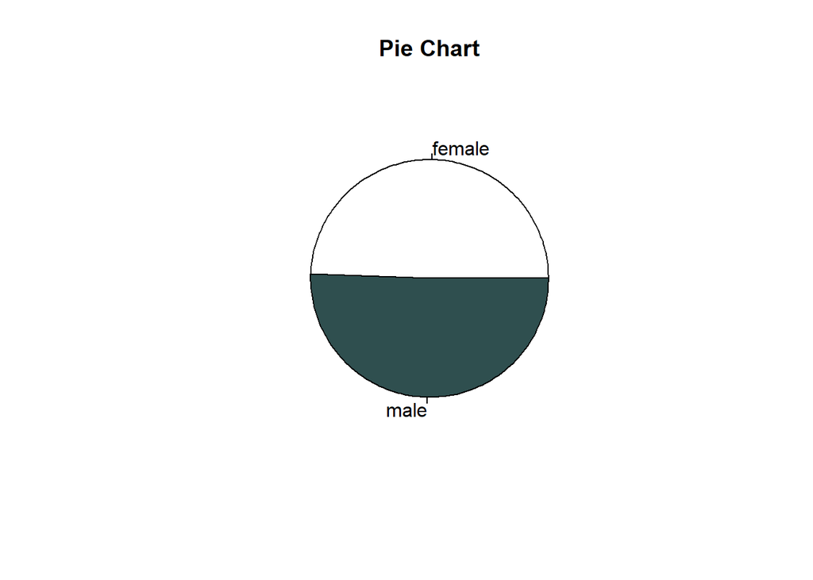

```r
pie(Proportion,
    radius = 0.7,
    main = "Pie Chart",
    border = "Black",
    col = c("white", "darkslategrey")
    )
```

We can also put a border around the pie chart, as follows :

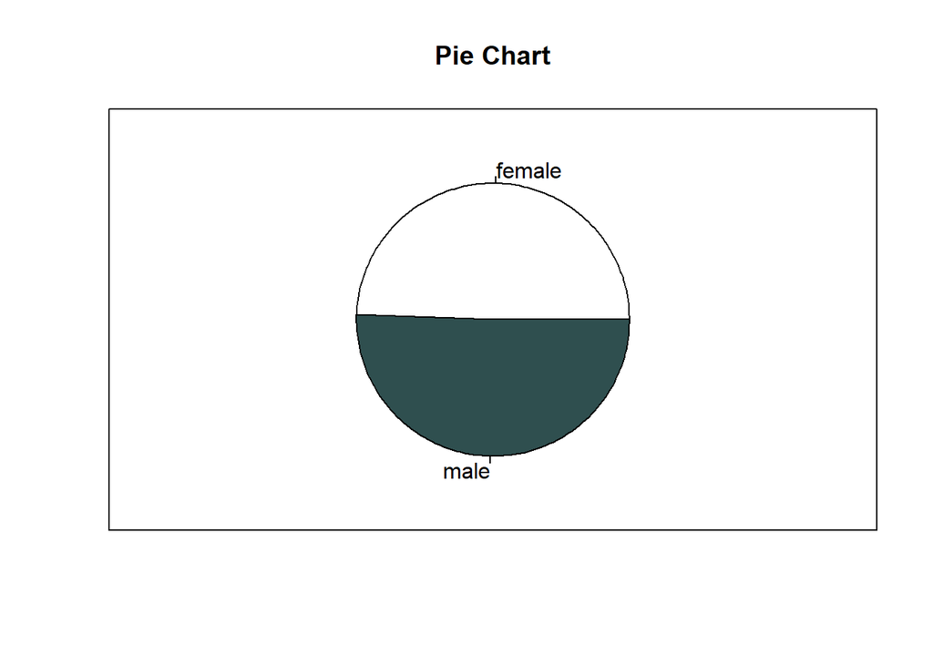

```r
pie(Proportion,
    radius = 0.7,
    main = "Pie Chart",
    border = "Black",
    col = c("white", "darkslategrey")
    )

box()
```

### Box Plots

A boxplot is appropriate for summarizing the distribution of a numeric variable.

To get help on boxplot in R :

```r
help("boxplot") #or,
?boxplot
```

A boxplot is the visual display of the 5 level summary of a numeric variable.

We can visually deduce the following metrices from a single boxplot :

1. Minimum value
2. 1st quartile
3. Median/2nd quartile
4. 3rd quartile
5. Maximum value

Let’s produce a boxplot for *“LungCap”* :

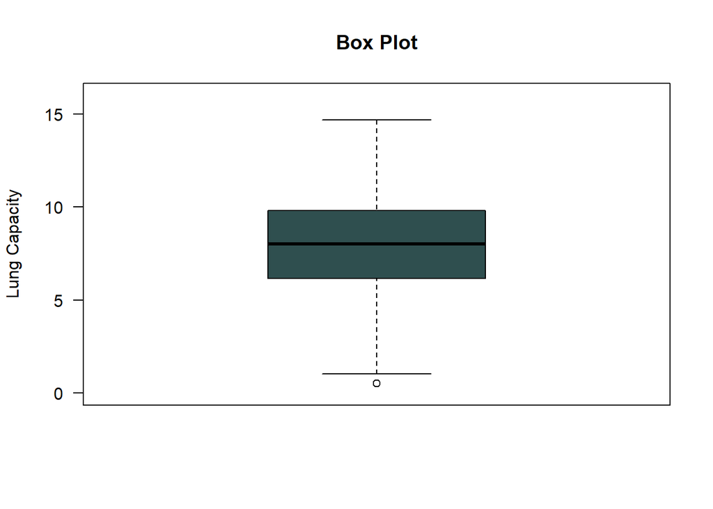

```r
boxplot(LungCap,
        main = "Box Plot",
        ylab = "Lung Capacity",
        ylim = c(0,16),
        las = 1,
        col = "darkslategrey",
        border = "black"
      )
```

We can get the numeric values of the boxplot summary, as follows :

```r
quantile(LungCap, probs = c(0, 0.25, 0.5, 0.75, 1))
```

```
##     0%    25%    50%    75%   100%
##  0.507  6.150  8.000  9.800 14.675
```

We can also compare the distribution of a numerical variable for different elements/categories of a categorical variable, using box plots.

Let’s say, we want to see the distribution of *“LungCap”* of *“Male”* and *“Females”* :

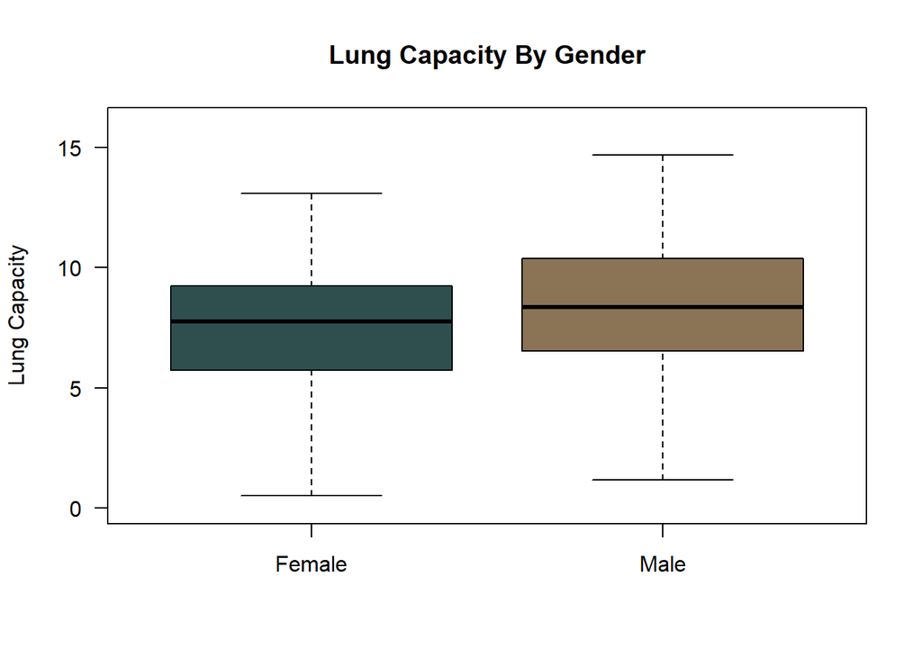

```r
boxplot(LungCap ~ Gender,
        main = "Lung Capacity By Gender",
        ylab = "Lung Capacity",
        xlab = NULL,
        names = c("Female", "Male"),
        ylim = c(0,16),
        las = 1,
        col = c("darkslategrey","burlywood4"),
        border = "black"
      )
```

If we want to see the boxplots horizontally, then, we can do so by passing `horizontal = TRUE` inside `boxplot()` function :

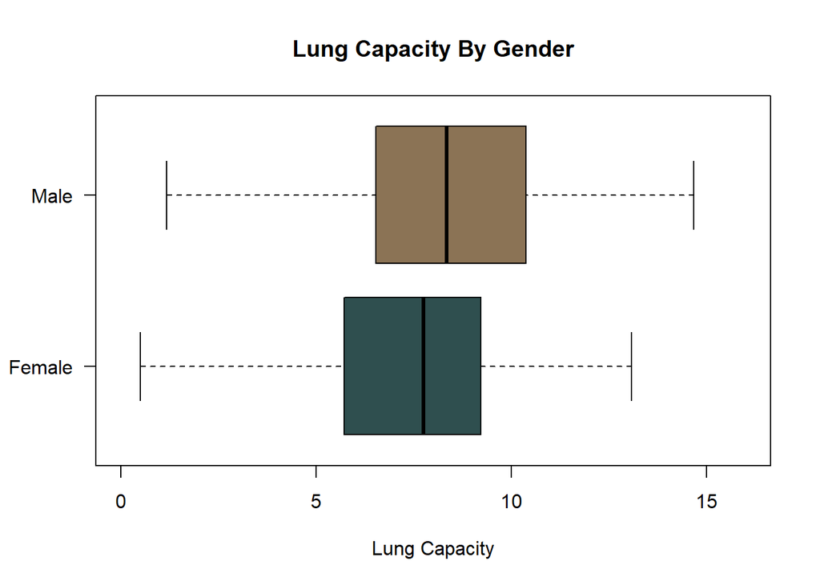

```r
boxplot(LungCap ~ Gender,
        main = "Lung Capacity By Gender",
        xlab = "Lung Capacity",
        ylab = NULL,
        names = c("Female", "Male"),
        ylim = c(0,16),
        las = 1,
        col = c("darkslategrey","burlywood4"),
        border = "black",
        horizontal = TRUE
      )
```

If we want see the *“LungCap”* of only *“Males”* then :

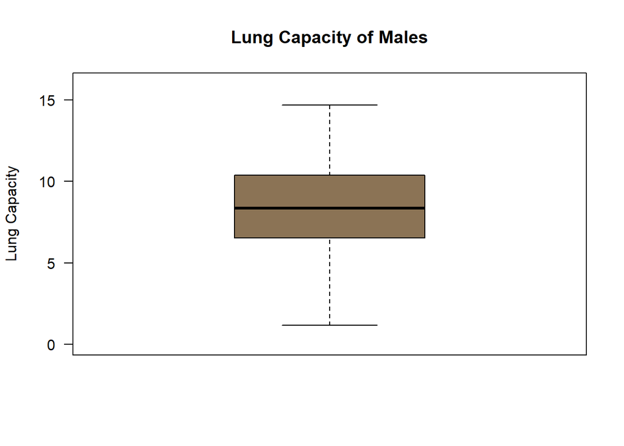

```r
boxplot(LungCap[Gender == "male"],
        main = "Lung Capacity of Males",
        ylab = "Lung Capacity",
        xlab = NULL,
        names = "Male",
        ylim = c(0,16),
        las = 1,
        col = "burlywood4",
        border = "black"
      )
```

#### Startified Box Plot

Startified boxplots are useful for examining the relationship between a categorical and a numeric variable, within strata/groups defined by the variable.

```r
AgeGroup = cut(Age,
               breaks = c(0,13,15,17,25),
               labels = c("<13", "14-15", "16-17","18+")
               )

levels(AgeGroup)
```

```
## [1] "<13"   "14-15" "16-17" "18+"
```

Now, let’s check whether the *“AgeGroup”* variable is working properly or, not by taking the first 5 elements from the *“Age”* category.

```r
Age[0:5]
```

```
## [1]  6 18 16 14  5
```

```r
AgeGroup[0:5]
```

```
## [1] <13   18+   16-17 14-15 <13
## Levels: <13 14-15 16-17 18+
```

So, we can see that our grouping works properly.

Now, let’s compare the lung capacity of smokers and non-smokers :

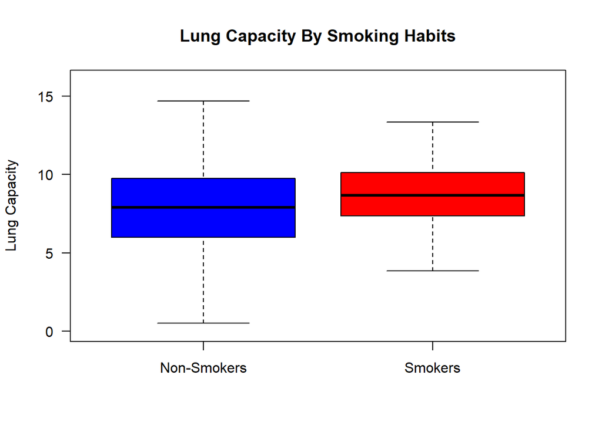

```r
boxplot(LungCap ~ Smoke,
        main = "Lung Capacity By Smoking Habits",
        ylab = "Lung Capacity",
        xlab = NULL,
        names = c("Non-Smokers", "Smokers"),
        ylim = c(0,16),
        las = 1,
        col = c("blue","red"),
        border = "black"
      )
```

We can see the that *“Non-Smokers”* have lower lung capacity than *“Smokers”* which seems incorrect and not taking the age factor into consideration might be the cause of this output.

Let’s compare the same output only for 18+ age group :

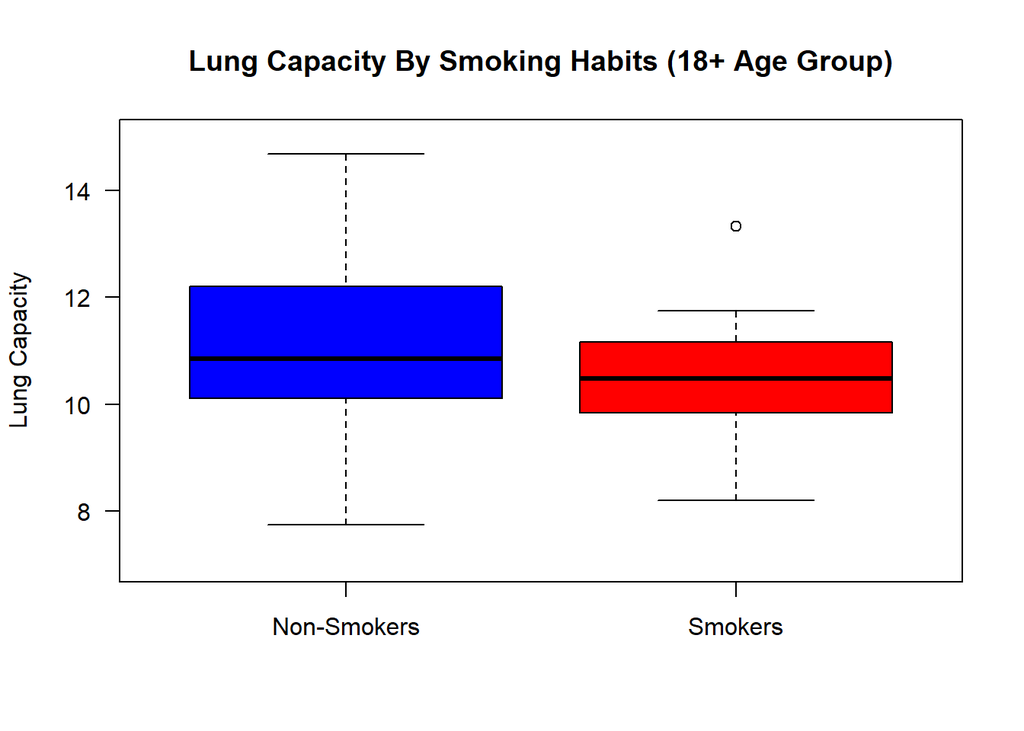

```r
boxplot(LungCap[Age >= 18] ~ Smoke[Age >= 18],
        main = "Lung Capacity By Smoking Habits (18+ Age Group)",
        ylab = "Lung Capacity",
        xlab = NULL,
        names = c("Non-Smokers", "Smokers"),
        ylim = c(7,15),
        las = 1,
        col = c("blue","red"),
        border = "black"
      )
```

Now, we got a more practical result, i.e.,among the 18+ age group, the lung capacity of non-smokers is higher than that of smokers

Now, let’s jump one step further and visualize the relationship between the lung capacity and smoking habits within each of the age strata.

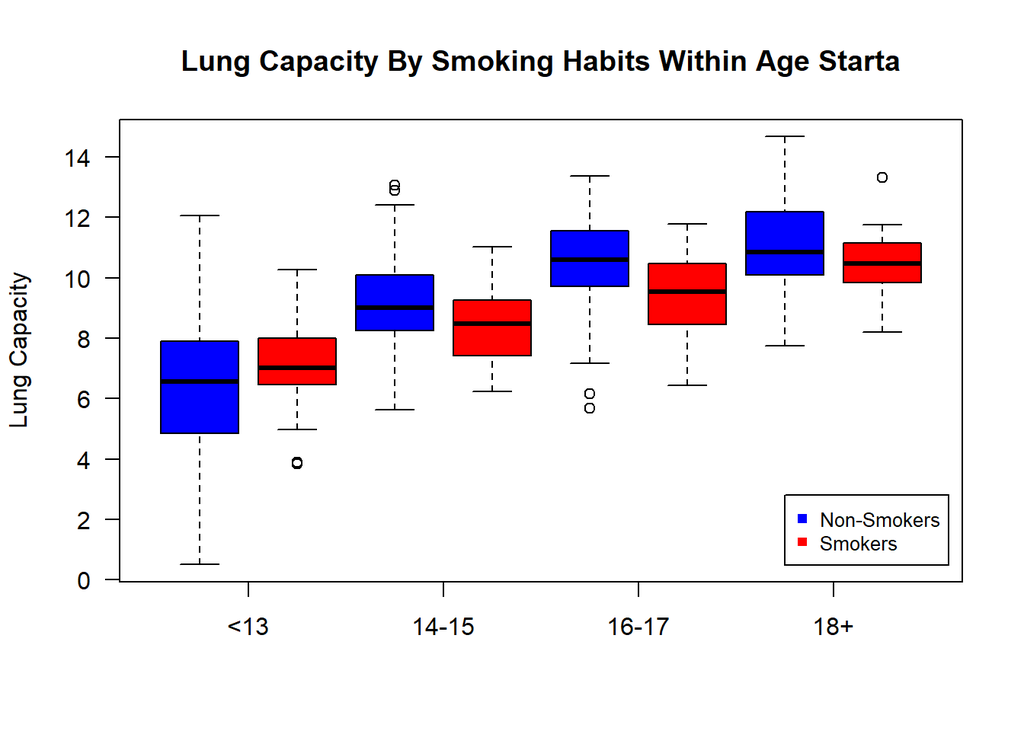

```r
boxplot(LungCap ~ Smoke * AgeGroup,
        main = "Lung Capacity By Smoking Habits Within Age Starta",
        ylab = "Lung Capacity",
        xlab = NULL,
        axes = FALSE,
        las = 2,
        col = c("blue","red"),
        border = "black"
      )
box()

axis(2, at = seq(0,20,2), seq(0,20,2), las = 1)
axis(1, at = c(1.5, 3.5, 5.5, 7.5), labels = c("<13", "14-15", "16-17","18+"))

legend(x = 7.0, y = 2.8,
       legend = c("Non-Smokers", "Smokers"),
       col =c("blue","red"),
       pch = 15, cex = 0.8)
```

### Histogram

A histogram is appropriate for summarizing the distribution of a numeric variable.

To get help on histogram in R :

```r
help("hist") #or,
?hist
```

Let’s plot a histogram for *“LungCap”* :

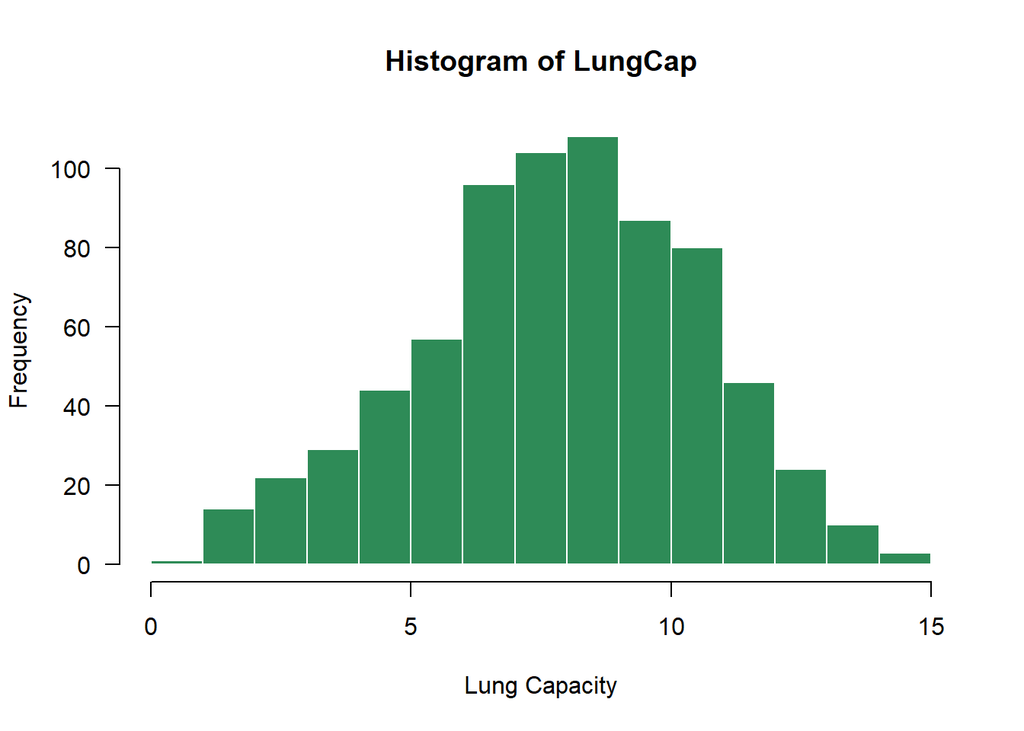

```r
hist(LungCap,
     xlab = "Lung Capacity",
     col = "seagreen",
     border = "white",
     las = 1
     )
```